# Radiation fast and slow

Benjamin Haley

March 30, 2015

## Is acute radiation most dangerous?

I will look at animal survival data and ask two central questions:

1. Are low dose-rate exposures safer than high dose-rate exposures?
2. Are fractionated exposures safer than acute exposures?

## Data

I will look at data that is comparable to atomic bomb survivor data. Exposures less than 4 Gy to low-LET radiation.

```r
# Filter
the_data <- the_data %>%
  filter(dose <= 4)

the_data <- the_data %>%
  group_by(study) %>%
  mutate(cluster_number = reorder(cluster_number)) %>%
  ungroup()
```

# Survival

First let us look at raw survivial curves for the included data.

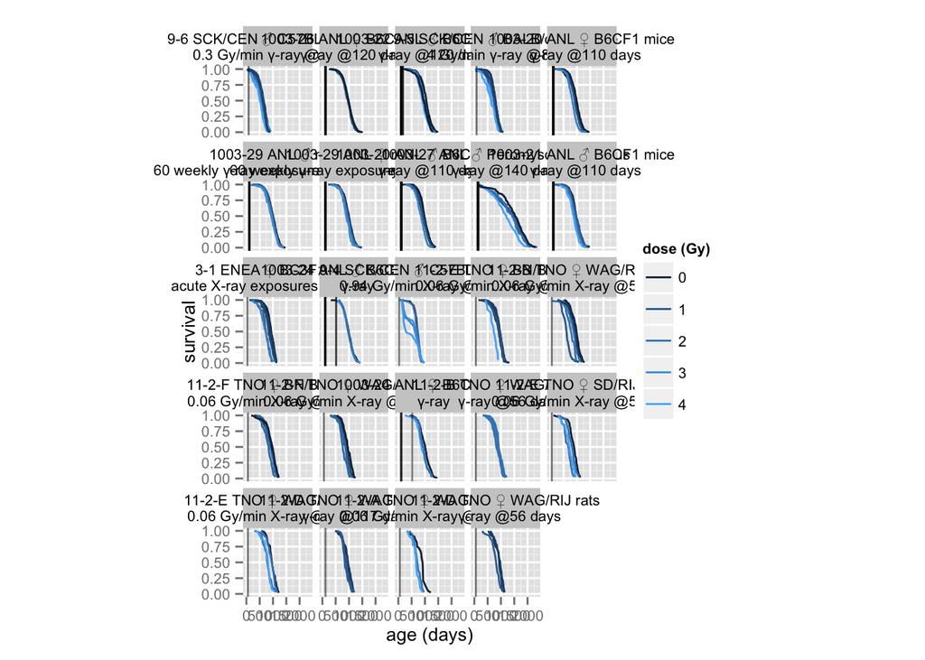

```r
# Calculate survival
the_data <- the_data %>%
  group_by(study, dose, group) %>%
  arrange(lifespan) %>%
  mutate(survival=rank(-lifespan) / length(lifespan))

# Organize strata by number of animals
order <- the_data %>%
  group_by(stratum) %>%
  summarize(n=length(stratum)) %>%
  arrange(-n) %>%
  select(stratum)
the_data$stratum <- factor(the_data$stratum, levels=order$stratum)

# Show survival
ggplot(the_data,
       aes(lifespan,
           survival,
           color=dose,
           group=group)) +
  geom_path() +
  facet_wrap(~ stratum) +
  scale_color_continuous(
    guide = guide_legend(title = "dose (Gy)"),
    trans = "sqrt"
  ) +
  geom_vline(
    aes(xintercept=treatment_age),
    alpha=0.5
  ) +
  expand_limits(x = -4) +
  theme(text = element_text(size = 10)) +
  xlab("age (days)") +
  theme(aspect.ratio=1)
```

Not much signt of acute death yet, thought it is fascinating that the shape of the dose response curves change, essentially they seem to linearize!